# Stat 480 - Homework #4

Your Name

2/13/2018

#### Submission Details

**Due date**: the homework is due before class on Thursday.

**Submission process**: submit both the R Markdown file and the corresponding html file on canvas. Please submit both the `.Rmd` and the `.html` files separately and do not zip the two files together.

#### Format example

1. The questions are numbered and in plain text.

An example solution is in the black box.

The grading guidelines are in the teal box. I will try to provide details on how many points the question is worth.

#### Bike rentals in DC

1. Download the RMarkdown file with these homework instructions to use as a template for your work. Make sure to replace “Your Name” in the YAML with your name.

+0.25 pt for YAML

```r
bikes <- read.csv("https://raw.githubusercontent.com/Stat480-at-ISU/Stat480-at-ISU.github.io/master/homework/data/bikes.csv")
```

+0.25 pt

3. Recode the variable `holiday` to be logical variables with `0` as `FALSE` and `1` as `TRUE`.

```r
bikes$holiday <- as.logical(bikes$holiday)
```

+1 pt  
-0.5 if done incorrectly

4. Create a variable `workingday` in that is `FALSE` if it is a holiday or the weekend (use `weekday` where 1 = Sunday, 2 = Monday, etc.). You may find De Morgan’s laws helpful here. Use ggplot to create a scatterplot comparing the number of registered bike rentals with the number of casual bike rentals. Map `workingday` to color. Interpret the result.

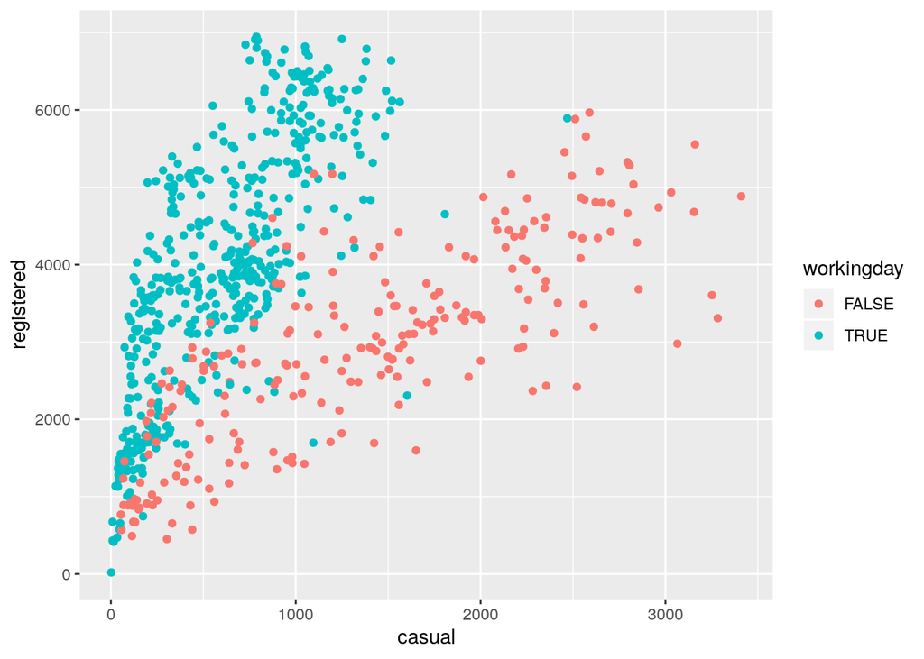

```r
bikes$workingday <- !((bikes$holiday) | (bikes$weekday %in% c(1,7))) # (A or B)^c
bikes$workingday <- !(bikes$holiday) & !(bikes$weekday %in% c(1,7)) # A^c and B^c

ggplot(bikes, aes(x = casual, y = registered, color = workingday)) +
  geom_point()
```

Example interpretation: From this scatterplot we can see that there, in general, appears to be a larger number of registered riders renting bikes than casual riders. This is especially true on work days.

+2.5 pt  
+1 pt for correctly creating the logical variable `workingday` +1 pt for plot +0.5 pt for interpretation

5. Recode the `year` variable so that the value 0 becomes 2011 and the value 1 becomes 2012.

```r
bikes$year[bikes$year == 0] <- 2011
bikes$year[bikes$year == 1] <- 2012
```

+1 pt  
-0.5 if done incorrectly

6. For each observation, verify that the variable `count` is equal to `casual` plus `registered`. You should be able to verify this without having to print out the columns. (Hint: one option is to use the function `any()`)

```r
any((bikes$casual + bikes$registered) != bikes$count)
```

```
## [1] FALSE
```

+1 pt  
-0.5 if done incorrectly

7. How does the number of casual riders renting bikes compare across the months? Use ggplot2 to draw side-by-side boxplots of `casual` by `month`. Interpret the result.

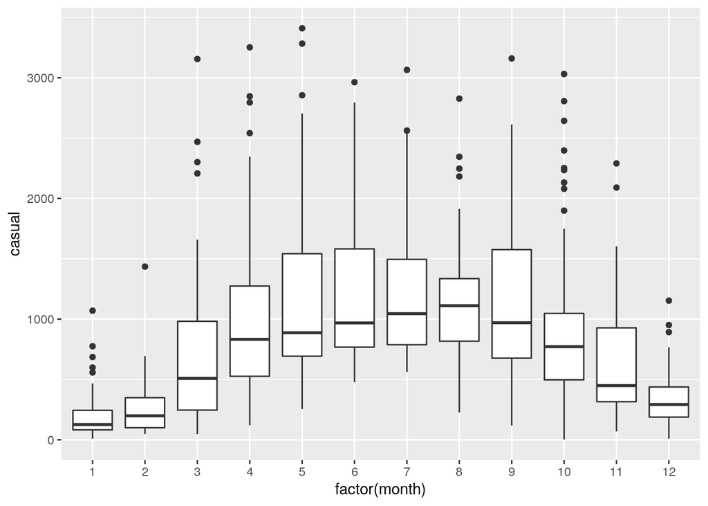

```r
ggplot(bikes, aes(x = factor(month), y = casual)) +
  geom_boxplot()
```

Example interpretation: The median number of of casual rentals is larger is the summer months (months ~5-9) than in the winter months. Additionally, from the boxplots, we can see that the distributions of number of casual rentals tend to be skewed with some larger outliers.

+1.5 pt  
+1 pt for plot +0.5 pt for interpretation

8. How does the number of rentals compare for different weather conditions? Recode the variable `weather` to be a factor with 1 - clear, 2 - mist, 3 - light_precip. Use ggplot2 to draw side-by-side boxplots of `count` by `weather` colored by `weather`. Interpret the result.

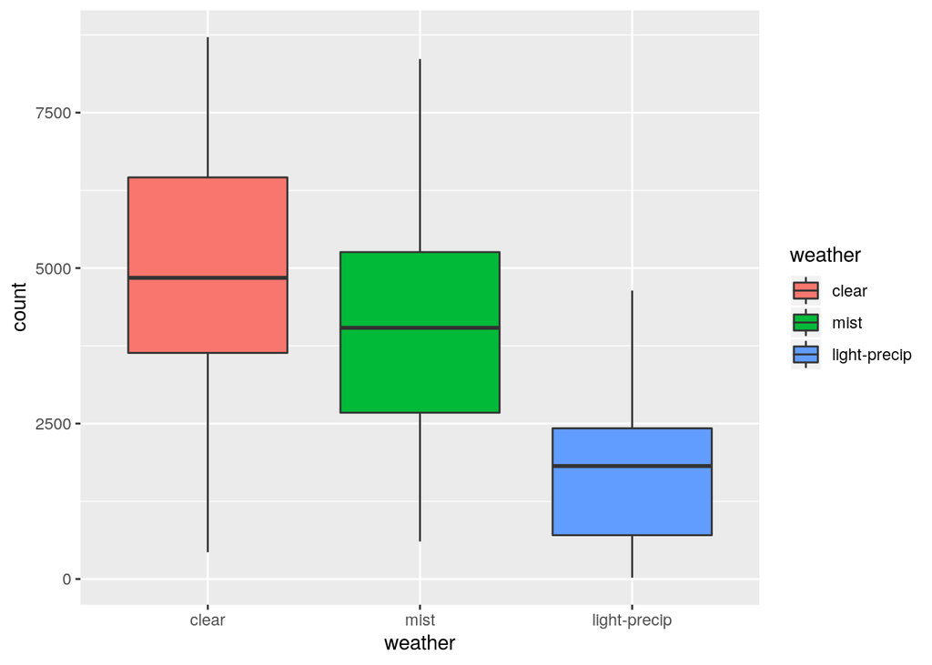

```r
bikes$weather <- factor(bikes$weather)
levels(bikes$weather) <- c("clear", "mist", "light-precip")

ggplot(bikes, aes(x = weather, count, fill = weather)) +
  geom_boxplot()
```

Example interpretation: The median number of of bike rentals is larger is when the weather is clear of misting, and smaller when there is light precipitation. Additionally, from the boxplots, we can see that the range of bike rentals when the weather is nicer is much larger than the range of bike rentals when there is light precipitation.

+2.5 pt  
+1 pt for factor with correct labels +1 pt for plot +0.5 pt for interpretation